# Project 2

Michelle Mondy

October 7, 2017

# Load the required packages

```r
library(RCurl)
library(tidyr)
library(dplyr)
```

# Load the csv file

I took a snippet of the H1B trend data CSV file from Sarah Wigodsky’s discussion board post example. Specifically, I pulled out the Trend of H1B Petitions Filed FY 2007 Through 2017: Beneficiary Industry (Top 30). This shows the number of filings per year by the top 30 industries.

I saved a copy of the original csv to my github site which can be found here: https://github.com/mmondy/MSDS/blob/master/DATA607/Week%206/h-1b-2007-2017-trend-tables.csv

```r
h1b <- data.frame(read.csv(text = getURL("https://raw.githubusercontent.com/mmondy/MSDS/master/DATA607/Week%206/h1bpetitionsindustry.csv"), header = T))
View(h1b)
```

# Transform the data into a tidy format

In order to do this, we need to use the tidyr and dplyr packages to put the data in a more usable format. Since the last column shows totals, I am going to drop this column as it will not be accurate once the data is transformed.

```r
tidy_h1b <-  select(h1b, -starts_with("Tot")) %>% gather("Year", "n", 2:12)
head(tidy_h1b)
```

```
##                                           Industry  Year     n
## 1             Custom Computer Programming Services X2007 83501
## 2                 Computer Systems Design Services X2007 14469
## 3 Colleges, Universities, and Professional Schools X2007 25770
## 4                             Engineering Services X2007  8258
## 5                  Other Computer Related Services X2007 10515
## 6           General Medical and Surgical Hospitals X2007  6785
```

# Analysis

With the data in this long format, I can plot the trend of industries by year. Since there are so many industries, I would like to subset the data for only the top 5.

```r
library(sqldf)
#Find the top 5 Industries overall
totals <- tidy_h1b %>% group_by(Industry) %>% summarise(total=sum(n))
arrange(totals, desc(total))
```

```
## # A tibble: 30 x 2
##                                                                Industry
##                                                                  <fctr>
##  1                                 Custom Computer Programming Services
##  2                                     Computer Systems Design Services
##  3                     Colleges, Universities, and Professional Schools
##  4                                                 Engineering Services
##  5                                      Other Computer Related Services
##  6                               General Medical and Surgical Hospitals
##  7                                                  Software Publishers
##  8                                     Elementary and Secondary Schools
##  9                            Investment Banking and Securities Dealing
## 10 Administrative Management and General Management Consulting Services
## # ... with 20 more rows, and 1 more variables: total <int>
```

```r
#Another way to do this:
sqldf("select Industry, sum(n) from tidy_h1b group by Industry order by 2 desc limit 5")
```

```
##                                           Industry sum(n)
## 1             Custom Computer Programming Services 999901
## 2                 Computer Systems Design Services 287933
## 3 Colleges, Universities, and Professional Schools 229053
## 4                             Engineering Services  69627
## 5                  Other Computer Related Services  66200
```

```r
top5 <- sqldf("select * from tidy_h1b where Industry in ('Custom Computer Programming Services', 'Computer Systems Design Services', 'Colleges, Universities, and Professional Schools', 'Engineering Services', 'Other Computer Related Services')")
```

Create the charts:

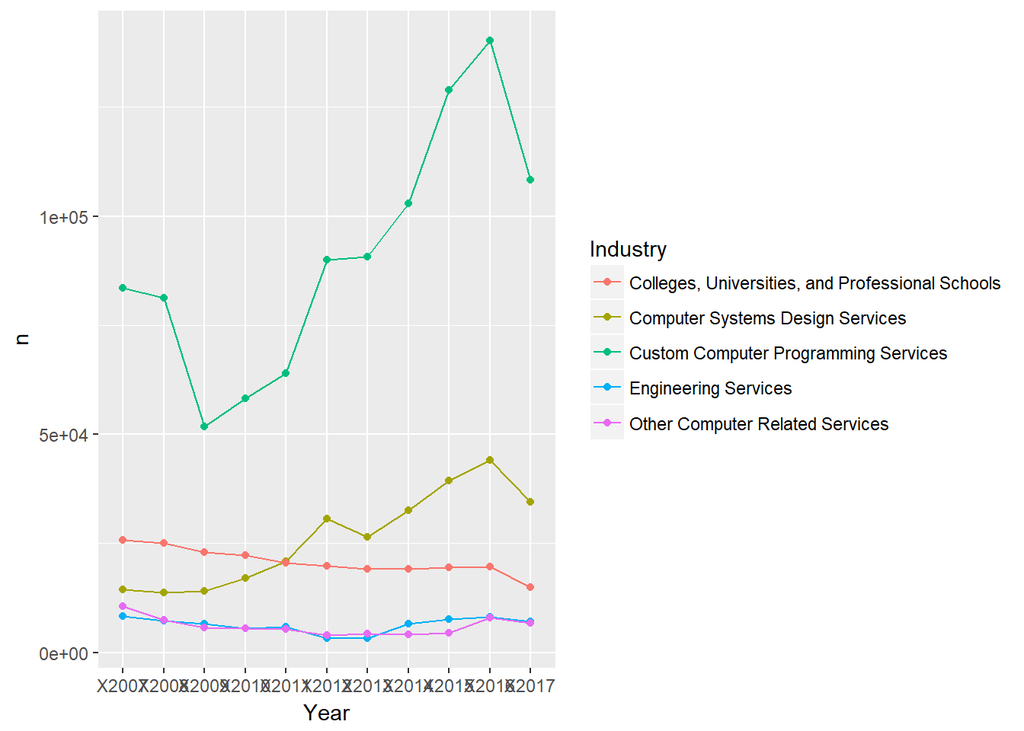

```r
library(ggplot2)
ggplot(data=top5, aes(x=Year, y=n, group=Industry, colour=Industry)) +
    geom_line() +
    geom_point()
```

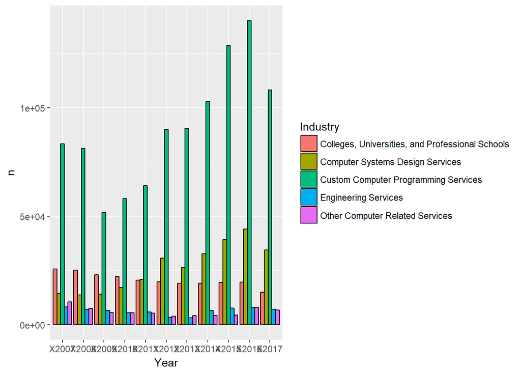

```r
ggplot(data=top5, aes(x=Year, y=n, fill=Industry)) +
    geom_bar(stat="identity", position=position_dodge(), colour="black")
```

# Conclusions

The beneficiary’s Industry for H1B Petitions Filed appear to be largely from Custom Computer Programming Services. Computer Systems Desgin Services appear to be somewhat related and following a similar trend. It’s interesting to note that of the top 5 industries, 3-4 are related to computer services.